# Student profiles that took the PISA 2012 test

### What is the structure of your dataset?

PISA 2012 data has the tests of 485,490 student representatives from 64 countries. 635 variables are evaluated.  
The main variables chosen are the type of population: native or emigrant, scores and truancy, among others.

### What are the main features of interest?

- Which continents and countries have the best and worst educational level?
- Immigrant students have a worse educational and social level than native students?
- Is absenteeism related to a worse educational and social level?
- Is wealth related to a better educational level?

### What features do you think will help support your investigation?

I expect that Europe has the highest mean education level, immigrants and natives have the same educational level, immigrants have lower wealth, and truancy is related with lower educational level and lower wealth.

### Distribution of Scores

```
(0, 40000)
```

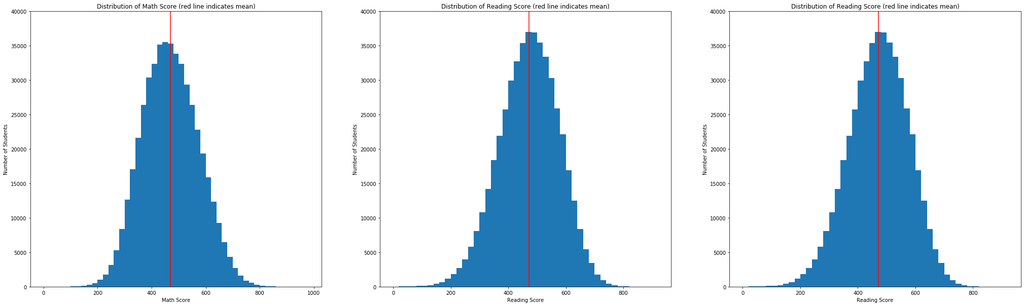

```python
# Look at the distribution of  Scores with a standard-scaled plot
base_color = sb.color_palette()[0]
plt.figure(figsize = [35,10])

plt.subplot(1,3,1)
binsize = 20
bins = np.arange(0, pisa['PV1MATH'].max()+binsize, binsize)
plt.hist(data=pisa, x='PV1MATH', bins = bins)
plt.title('Distribution of Math Score (red line indicates mean)')
plt.xlabel('Math Score')
plt.ylabel('Number of Students')
plt.axvline(pisa['PV1MATH'].mean(), color='r')
plt.ylim((0,40000))

plt.subplot(1,3,2)
binsize = 20
bins = np.arange(0, pisa['PV1READ'].max()+binsize, binsize)
plt.hist(data=pisa, x='PV1READ', bins = bins)
plt.title('Distribution of Reading Score (red line indicates mean)')
plt.xlabel('Reading Score')
plt.ylabel('Number of Students')
plt.axvline(pisa['PV1READ'].mean(), color='r')
plt.ylim((0,40000))

plt.subplot(1,3,3)
binsize = 20
bins = np.arange(0, pisa['PV1READ'].max()+binsize, binsize)
plt.hist(data=pisa, x='PV1READ', bins = bins)
plt.title('Distribution of Reading Score (red line indicates mean)')
plt.xlabel('Reading Score')
plt.ylabel('Number of Students')
plt.axvline(pisa['PV1READ'].mean(), color='r')
plt.ylim((0,40000))
```

The distribution of the marks take on a range of values between 0 and 900 in all the subjects, the unimodal distribution being very similar between them, as well as the average marks (between 469 and 476 points).

### Distribution of Truancy

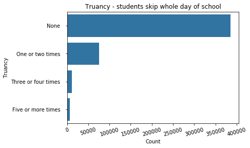

```python
# bar chart of the categorical variable TRUANCY - skip whole school day
base_color = sb.color_palette()[0]
sb.countplot(data=pisa, y='ST09Q01', color=base_color)
plt.xticks(rotation=15)
plt.title('Truancy - students skip whole day of school')
plt.xlabel('Count')
plt.ylabel('Truancy')
```

Truancy measures the days that a student is absent from class.  
Most of the students are not absent from classes.

### Relationship between Scores

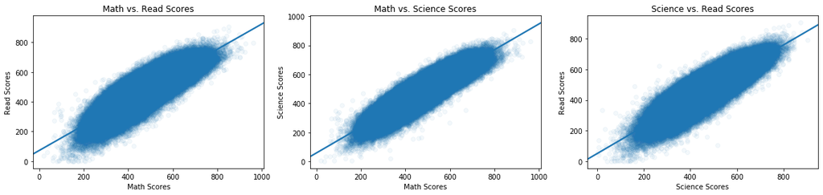

```python
# Scatter Scores
plt.figure(figsize = [20,4])
# scatter score MATH AND READING.
plt.subplot(1,3,1)
sb.regplot(data=pisa,x='PV1MATH',y='PV1READ', scatter_kws={'alpha':1/20})
plt.title('Math vs. Read Scores')
plt.xlabel('Math Scores')
plt.ylabel('Read Scores')

# scatter score MATH AND SCIENCE.
plt.subplot(1,3,2)
sb.regplot(data=pisa,x='PV1MATH',y='PV1SCIE', scatter_kws={'alpha':1/20})
plt.title('Math vs. Science Scores')
plt.xlabel('Math Scores')
plt.ylabel('Science Scores')

# scatter score SCIENCE AND READ.
plt.subplot(1,3,3)
sb.regplot(data=pisa,x='PV1SCIE',y='PV1READ', scatter_kws={'alpha':1/20})
plt.title('Science vs. Read Scores')
plt.xlabel('Science Scores')
plt.ylabel('Read Scores')
```

As expected, the correlation between the subjects is linear, strong and positive: the higher a student's math score, the better the student's science or reading score.

### Relationship between Scores and Truancy

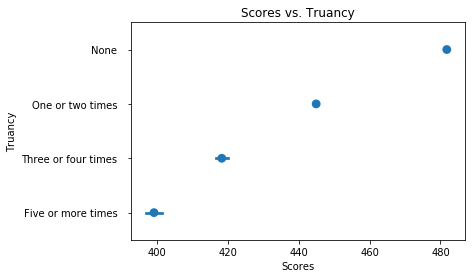

```python
# Create a mean score column
pisa['Score'] = (pisa.PV1MATH + pisa.PV1READ + pisa.PV1SCIE)/3

#  Scores vs. Truancy pointplot
sb.pointplot(data=pisa, x='Score',y='ST09Q01',linestyles="")
plt.title('Scores vs. Truancy')
plt.xlabel('Scores')
plt.ylabel('Truancy')
```

The shape of the distributions are quite similar.  
There is a positive correlation between those who score the most and the few who are absent from school.

### Relationship between Scores and type of population

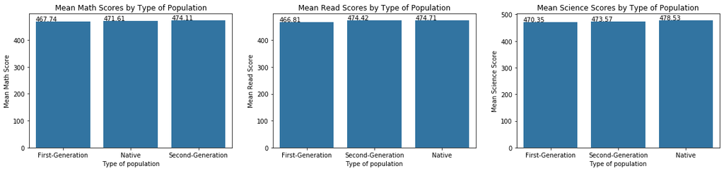

```python
# Mean Scores by type of population
base_color = sb.color_palette()[0]
plt.figure(figsize = [20,4])

# Type of population, IMMIG, VS Math Score, PV1MATH
plt.subplot(1,3,1)
pop_math = pisa.groupby('IMMIG').PV1MATH.mean().rename('Mean_Math_Score').reset_index().sort_values('Mean_Math_Score')
ax = sb.barplot(data= pop_math, x='IMMIG', y='Mean_Math_Score', color= base_color)
plt.title('Mean Math Scores by Type of Population')
plt.xlabel('Type of population')
plt.ylabel('Mean Math Score')


for p in ax.patches:
    ax.annotate(str(round(p.get_height(),2)), (p.get_x() * 1.005, p.get_height() * 1.005))

# Type of population, IMMIG, VS Read Score, PV1READ
plt.subplot(1,3,2)
pop_math = pisa.groupby('IMMIG').PV1READ.mean().rename('Mean_Read_Score').reset_index().sort_values('Mean_Read_Score')
ax = sb.barplot(data= pop_math, x='IMMIG', y='Mean_Read_Score', color= base_color)
plt.title('Mean Read Scores by Type of Population')
plt.xlabel('Type of population')
plt.ylabel('Mean Read Score')

for p in ax.patches:
    ax.annotate(str(round(p.get_height(),2)), (p.get_x() * 1.005, p.get_height() * 1.005))

# Type of population, IMMIG, VS Science Score, PV1SCIE
plt.subplot(1,3,3)
pop_math = pisa.groupby('IMMIG').PV1SCIE.mean().rename('Mean_Science_Score').reset_index().sort_values('Mean_Science_Score')
ax = sb.barplot(data= pop_math, x='IMMIG', y='Mean_Science_Score', color= base_color)
plt.title('Mean Science Scores by Type of Population')
plt.xlabel('Type of population')
plt.ylabel('Mean Science Score')

for p in ax.patches:
    ax.annotate(str(round(p.get_height(),2)), (p.get_x() * 1.005, p.get_height() * 1.005))
```

Broken down by population (natives, first generation of immigrants and second generation of immigrants) differences in scores are observed.

First Generation of immigrants is the type with the lowest scores in all the subjects while Natives are the type with the highest scores in Reading and Science.

### Immigrants vs. correlated Variables

```
(14.5, -0.5)
```

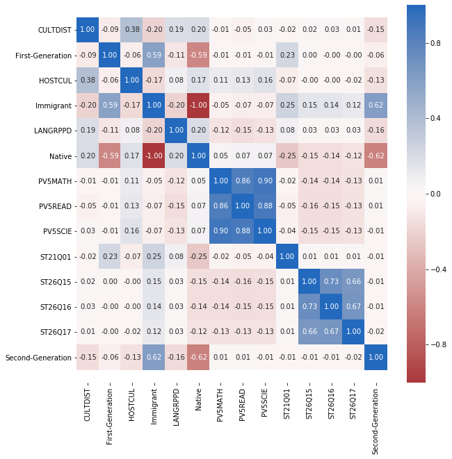

```python
# We bring Second-Generation and First-Generation together

# FIND FEATURES CORRELATEED WITH IMMIGRANTS
# Exploring correlation matrix with IMMIGRANTS
#1. create a column for immigrants (just two: native and immigrants)
#2. correlations > 0.1

#1.1 creating immigration dummies
immig_dummies=pd.get_dummies(pisa['IMMIG'])

# 1.2.create new column. new column is a duplicate of Native column
# replace 1 for 0 andd 0 for 1 in duplicate of native column
immig_dummies['Immigrant'] = immig_dummies['Native']

# 1.3 create immigrant column
immig_dummies['Immigrant'] = immig_dummies['Immigrant'].map({0: 1, 1:0})

#1.4 concat dummies with pisa
pisa=pd.concat([pisa,immig_dummies],axis=1)
# 2. make correlation matrix
corrMatrix = pisa.corr()
#2.1 Get all variables that have a correlation above 0.07 with "immigrant".
immig_corr = corrMatrix.Immigrant[abs(corrMatrix.Immigrant)>0.10]
#2.2 get list of columns
col_list_ic = immig_corr.index.tolist()
#2.3extend list to include science and maths scpres
col_list_ic.extend(["PV5SCIE","PV5MATH",'PV5READ'])
col_list_ic.sort()
#2.4make correlation matrix
corrMatrix_immigrant = pisa[col_list_ic].corr()
#2.5 plot heatmap of features correlated with gender
plt.figure(figsize = [10,10])

ht = sb.heatmap(corrMatrix_immigrant, annot = True,cmap = 'vlag_r',fmt = '.2f',center = 0)
ht.set_ylim(len(corrMatrix_immigrant)+0.5, -0.5)
```

Given that there is a difference between the type of population in scores, we will observe in greater depth which variables are significantly correlated with immigrant students (first and second generation).

The feeling of equality, between immigrants and natives, is felt less by immigrants than by natives.

### Scores vs. Countries, Type of Population and Wealth

```
(0, 700)
```

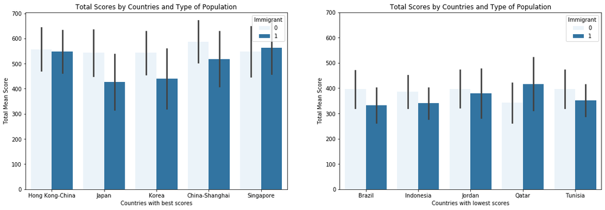

```python
# get top and worst 'Total score' countries
score_countries = pisa.groupby('CNT').Score.mean().sort_values(ascending=False)
top_score_countries = score_countries.iloc[0:5]
worst_score_countries = score_countries.iloc[-6:-1]

# get index
top_score_countries_df = pisa[pisa['CNT'].isin(top_score_countries.index)]
worst_score_countries_df = pisa[pisa['CNT'].isin(worst_score_countries.index)]

# rename Type of population
top_score_countries_df.replace

# plot
base_color = sb.color_palette()[0]
plt.figure(figsize = [19,6])

plt.subplot(1,2,1)
sb.barplot(data=top_score_countries_df,x='CNT',y='Score',hue='Immigrant', ci='sd', color= base_color)
plt.title('Total Scores by Countries and Type of Population')
plt.xlabel('Countries with best scores')
plt.ylabel('Total Mean Score')
plt.legend(title='Immigrant')

plt.subplot(1,2,2)
sb.barplot(data= worst_score_countries_df,x='CNT',y='Score',hue='Immigrant', ci='sd', color= base_color)
plt.title('Total Scores by Countries and Type of Population')
plt.xlabel('Countries with lowest scores')
plt.ylabel('Total Mean Score')
plt.legend(title='Immigrant')
plt.ylim((0,700))
```

*Legend clarification for Immigrant:*

- *0 means no immigrant, that is, Native.*
- *1 means Immigrant (first or second generation).*

We select the countries with the highest and worst scores.  
There is a difference of more than 100 points between the highest and lowest scores countries.  
Usually, natives get a higher total score in countries. However, Singapore and Qatar have immigrants with higher scores.  
All top scored countries are Asian but 3 of the worst scored countries are also asians. So, this continent has the highest and lowest score cuontries.

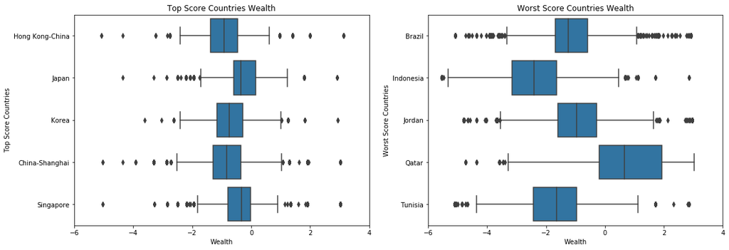

```python
# Looking at top score countries by wealth
plt.figure(figsize = [18,6])
plt.subplot(1,2,1)
sb.boxplot(data=pisa[pisa['CNT'].isin(top_score_countries.index)],y='CNT',x='WEALTH',color=base_color)
plt.xlim((-6,4))
plt.title('Top Score Countries Wealth')
plt.xlabel('Wealth')
plt.ylabel('Top Score Countries')

# Looking at worst score countries by wealth
plt.subplot(1,2,2)
sb.boxplot(data=pisa[pisa['CNT'].isin(worst_score_countries.index)],y='CNT',x='WEALTH',color=base_color)
plt.xlim((-6,4))
plt.title('Worst Score Countries Wealth')
plt.xlabel('Wealth')
plt.ylabel('Worst Score Countries')
```

Are top score countries wealthier than worst scored countries?

Countries with fewer scores have less wealth, except Qatar. Yes there is a positive correlation in most cases.

### Wealth vs. Score and Type of Population

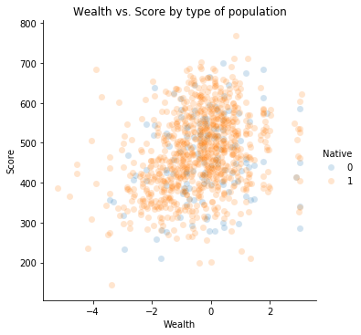

```python
# Scatter Score vs. Wealth
samples = np.random.choice(pisa.shape[0],1000,replace=False)
pisa_samp = pisa.loc[samples,:]
plt.figure(figsize = [15,4])

g = sb.FacetGrid(pisa_samp, hue="Native", height=5)
g.map(plt.scatter, "WEALTH", "Score", s=50, alpha=.2, linewidth=.5, edgecolor="white")
g.add_legend();
plt.title('Wealth vs. Score by type of population')
plt.xlabel('Wealth')
```

*Legend clarification for Native:*

- *0 means immigrant (first or second generation).*
- *1 means native.*

We analyze whether the level of wealth affects population types and their corresponding differences in scores.

The natives have a higher poverty rate than the immigrants, placing their interval at almost two points less than wealth.

The highest Native and Immigrant scores occur in the same wealth range.

Immigrant and Native American scores seem uncorrelated with wealth. Most of the scores are in a wealth interval of [-2.2].

We add **Truancy** to this list of variables to see if it affects absent more or less with the other variables. Truancy is divided into:

- None: no truancy
- One or two times: one or two truancy days
- Three or four times: three or four truancy days
- Five or more times: five or more truancy days

Breaking down by truancy, it can be seen that the greater the truancy, there is a small correlation with less wealth and a clear relationship with a lower score among immigrants.

Immigrants who are not absent or only absent once or twice have a more similar distribution of wealth, regardless of the score obtained.

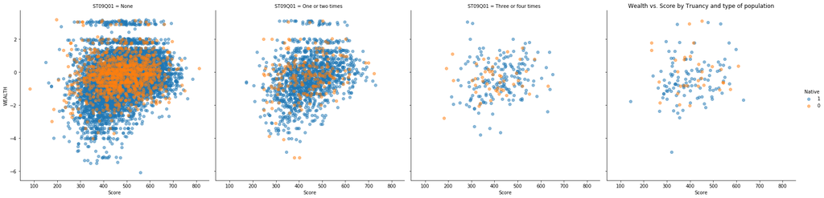

```python
# Scatterplots of wealth vs Score split by Truancy and Type of Population
samples = np.random.choice(pisa.shape[0],10000,replace=False)
pisa_samp = pisa.loc[samples,:]

truancy_order = ['None','One or two times','Three or four times','Five or more times']
truancy_cat = pd.api.types.CategoricalDtype(ordered=True, categories=truancy_order)
pisa.ST09Q01.astype(truancy_cat)

g = sb.FacetGrid(data = pisa_samp, hue='Native',col = 'ST09Q01', hue_order=[1,0], size = 6)
g.map(sb.regplot, "Score", 'WEALTH', fit_reg = False, scatter_kws = {'alpha' : 0.5})
g.add_legend();
plt.title('Wealth vs. Score by Truancy and type of population')
```

### Difference in scores between Type of Population vs. Truancy

```
(0, 26)
```

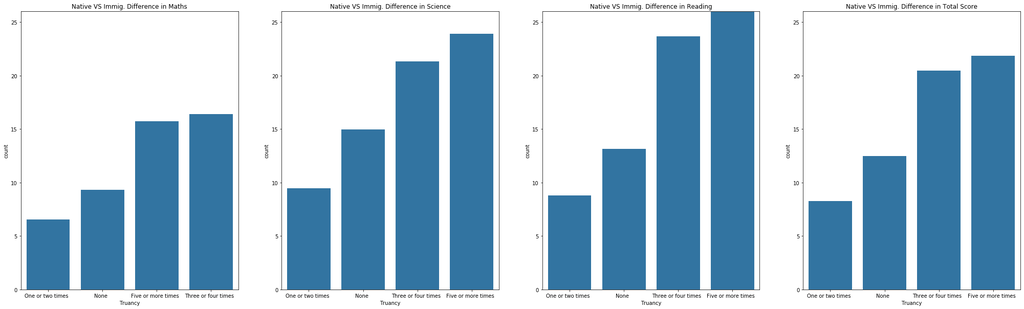

```python
# Native - Immigrants scores vs. Truancy
plt.figure(figsize = [35,10])

base_color = sb.color_palette()[0]
immig_diff="PV1MATH_diff"
plt.subplot(1,4,1)
gc = sb.barplot(y=immig_diff,x="ST09Q01",data=immig_truancy_scores_diff.sort_values(immig_diff).reset_index(),color = base_color)
plt.title("Native VS Immig. Difference in Maths")
plt.ylabel("count")
plt.xlabel("Truancy")
plt.ylim((0,26))

immig_diff="PV1SCIE_diff"
plt.subplot(1,4,2)
gc = sb.barplot(y=immig_diff,x="ST09Q01",data=immig_truancy_scores_diff.sort_values(immig_diff).reset_index(),color = base_color)
plt.title("Native VS Immig. Difference in Science")
plt.ylabel("count")
plt.xlabel("Truancy")
plt.ylim((0,26))

immig_diff="PV1READ_diff"
plt.subplot(1,4,3)
gc = sb.barplot(y=immig_diff,x="ST09Q01",data=immig_truancy_scores_diff.sort_values(immig_diff).reset_index(),color = base_color)
plt.title("Native VS Immig. Difference in Reading")
plt.ylabel("count")
plt.xlabel("Truancy")
plt.ylim((0,26))

immig_diff="Score_diff"
plt.subplot(1,4,4)
gc = sb.barplot(y=immig_diff,x="ST09Q01",data=immig_truancy_scores_diff.sort_values(immig_diff).reset_index(),color = base_color)
plt.title("Native VS Immig. Difference in Total Score")
plt.ylabel("count")
plt.xlabel("Truancy")
plt.ylim((0,26))
```

To analyze more clearly the difference in scores between natives and immigrants regarding truancy, we calculated the differences in scores between them for the subjects. All the differences are positive (Natives - Immigrants), therefore, the natives average better scores in all the subjects.

The smallest difference in scores between natives and immigrants occurs among those who skip classes once or twice.

If you skip classes more than once or twice, the difference in scores increases between natives and immigrants.

Regarding subjects, the highest score difference is found in Science for those who do not skip any class. The differences in Reading are the most noticeable for those who skip more classes.